# Statewise Covid-19 Population

Tracy Tai, Olachi Mbara, Luong Tran Thanh Quan

### Introduction

As Covid-19 spreads through the world, many people have suffered in this pandemic. As a result, people have changed their life style dramatically to stay healthy, including work from home, online teaching courses, and so on. Economics have also encountered tremendous challenges. Restaurants, shopping malls and gyms are all closed to keep Covid-19 from spreading, and resulted in companies facing great loss. In this project, we want to use data visualization to show how Covid-19 effect individuals and economy in each state, and compare data from each state.

### Summary

In our analysis, California has the most Covid-19 infected cases among other states, with 930628 Covid-19 cases. It in our commonsense that state with high civil population are more likely to have a high Covid-19 infected population, and our data and graph also supports this conclusion. The lowest Covid-19 cases is 2219 in Vermont. In our data set, the ten states with most Covid-19 cases are Arizona, California, Florida, Georgia, Illinois, North Carolina, New York, Tennessee, Texas, Wisconsin. Therefore, the number of Covid-19 infected people is related to the civil population of a state. Under Covid-19, we should all follow safety instructions and stay healthy for the sake of ourselves and our families, especially when you are living in a state with large Covid-19 cases.

### Aggregated Table

| state | stateGDP | population | density |
| --- | --- | --- | --- |
| California | 3018337 | 39613500 | 254.2929 |
| Texas | 1818585 | 29730300 | 113.8080 |
| New York | 1701399 | 19300000 | 409.5404 |
| Florida | 1059144 | 21944600 | 409.2233 |
| Illinois | 879947 | 12569300 | 226.3964 |
| Pennsylvania | 803307 | 12804100 | 286.1699 |
| Ohio | 689139 | 11714600 | 286.6939 |
| New Jersey | 634721 | 8874520 | 1206.7609 |
| Georgia | 601503 | 10830000 | 188.3053 |
| Washington | 576624 | 7796940 | 117.3248 |
| Massachusetts | 575635 | 6912240 | 886.1846 |
| North Carolina | 575605 | 10701000 | 220.1037 |
| Virginia | 544348 | 8603980 | 217.8774 |
| Michigan | 537087 | 9992430 | 176.7352 |
| Maryland | 417776 | 6065440 | 624.8522 |
| Colorado | 376994 | 5893630 | 56.8653 |
| Minnesota | 374920 | 5706400 | 71.6641 |
| Tennessee | 373663 | 6944260 | 168.4069 |
| Indiana | 371629 | 6805660 | 189.9643 |
| Arizona | 355311 | 7520100 | 66.2016 |
| Wisconsin | 342470 | 5852490 | 108.0633 |
| Missouri | 323287 | 6169040 | 89.7419 |
| Connecticut | 279653 | 3552820 | 733.7505 |
| Louisiana | 255492 | 4627000 | 107.0966 |
| Oregon | 243085 | 4289440 | 44.6873 |
| South Carolina | 234367 | 5277830 | 175.5707 |
| Alabama | 224654 | 4934190 | 97.4270 |
| Kentucky | 211621 | 4480710 | 113.4759 |
| Oklahoma | 203250 | 3990440 | 58.1739 |
| Iowa | 192608 | 3167970 | 56.7157 |
| Utah | 180862 | 3310770 | 40.2917 |
| Kansas | 169558 | 2917220 | 35.6807 |
| Nevada | 168752 | 3185790 | 29.0195 |
| Arkansas | 129812 | 3033950 | 58.3059 |
| Nebraska | 124742 | 1952000 | 25.4087 |
| Mississippi | 115749 | 2966410 | 63.2187 |
| New Mexico | 101452 | 2105000 | 17.3540 |
| Hawaii | 93419 | 1406430 | 218.9678 |
| New Hampshire | 86046 | 1372200 | 153.2671 |
| West Virginia | 79168 | 1767860 | 73.5444 |
| Idaho | 78640 | 1860120 | 22.5079 |
| Delaware | 76537 | 990334 | 508.1242 |
| Maine | 65349 | 1354520 | 43.9166 |
| Rhode Island | 61341 | 1061510 | 1026.6054 |
| North Dakota | 55657 | 770026 | 11.1596 |
| Alaska | 54851 | 724357 | 1.2694 |
| South Dakota | 52544 | 896581 | 11.8265 |
| Montana | 49635 | 1085000 | 7.4547 |
| Wyoming | 39899 | 581075 | 5.9847 |
| Vermont | 34154 | 623251 | 67.6197 |

In this table, we concluded several infomation we used to compute our analysis. We ranked the states by its state GDP, and then added population and density column to see how we can generate useful information from these values. This table can be compared with our first graph, to see if there’s a relationship between these values and Covid-19 cases. Some insights from this table would be the relationship found between state GDP, state density and population. As population increases, state GDP are likely to increase as well.The top five states with highest stateGDP also have a high population. On the other hand, state density did not relate to stateGDP as we predicted.

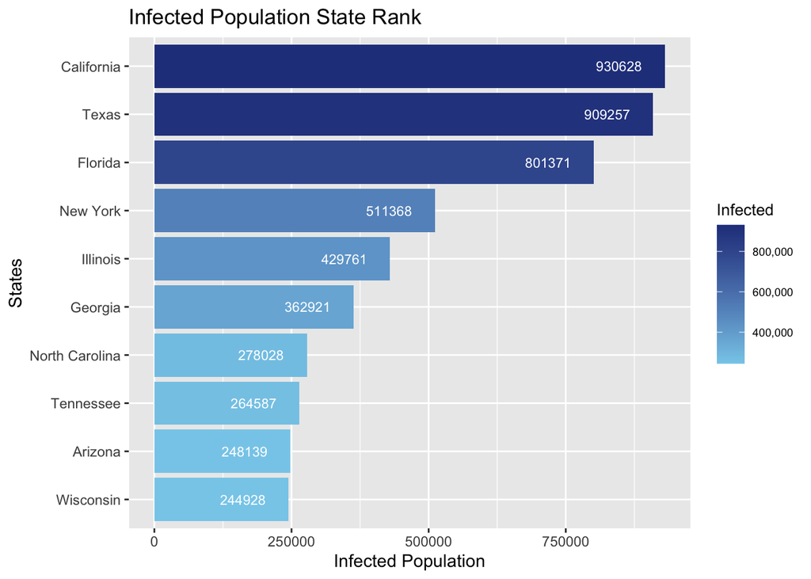

[figure not shown]

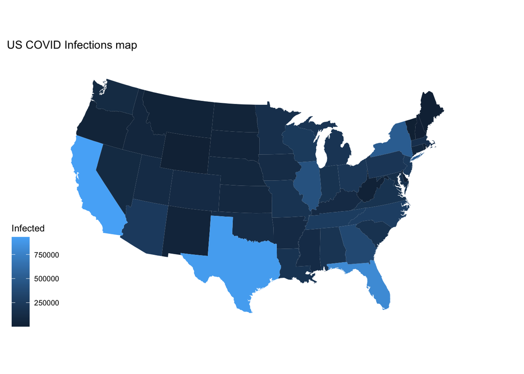

This chart was intended to show how Covid-19 infected population spreads throughout the country. This map presented the distribution of Covid-19 infected population, and be aware of the states with high infected populations. As we can see from this map, we could conclude that California and Texas are states with large Covid-19 infected population. We should all stay safe and protect ourselves in this situation.